# Aligning an observed (field) to a predicted (drone) stem map with the `ofo` package

Author

Derek Young

Published

June 14, 2024

## Purpose

To determine the accuracy of a “predicted” (drone-derived) stem map, we need to compare it to an “observed” (field inventory) stem map. Each of these datasets is collected in such a way that internally, the tree positions should be accurate relative to each other. However, the datasets may not have *globally* accurate georegistratation, which means that the predicted and observed tree maps may not be aligned. In turn, this means that any comparison between the two (e.g., to evaluate the accuracy of the predicted map) may be biased due to misalignment. Thus, we first need to align the two maps before we can compare them. This vignette demonstrates how to align the two maps using the `ofo` package.

## Setup

Load the the `ofo` package (which is the repo that this vignette’s source file is in, so we can use `devtools::load_all()` to load all the package’s functions).

```r
devtools::load_all()
```

## Generating simulated tree maps

To demonstrate alignment, we will simulate a predicted (drone-derived) and observed (traditional field inventory) stem map. The field-based map is more spatially constrained. The stem map simulation function has arguments to control the plot size, tree density, tree clumping, rate of false positives (drone-detected trees that are not real), rate of false negatives (real trees that are not detected by drone), horizontal noise, and vertical noise. There is an option to exclude the simulated observed trees that are underneath a neighbor tree, as these are presumably not observed by drone (in fact, they are always removed from the simulated drone dataset) and thus excluding them likely improves alignment. Finally, the user supplies a known x-y offset by which the observed map is shifted relative to the predicted map. This is the offset we will attempt to recover with the alignment function.

```r
sim = simulate_tree_maps(trees_per_ha = 300,
                         trees_per_clust = 5,
                         cluster_radius = 5,
                         obs_extent = 60,
                         pred_extent = 300,
                         horiz_jitter = 3,
                         vert_jitter = 5, # max of 5 or some simulated trees will be below ground
                         false_pos = 0.25,
                         false_neg = 0.25,
                         drop_observed_understory = TRUE,
                         shift_x = -9.25,
                         shift_y = 15.5)
```

The result is a list with two data frames, `obs` and `pred`, each with columns `x`, `y`, and `z` (plus some others relating to determineing whether a tree is in the understory or overstory).

```r
head(sim$obs)
```

```
            x          y         z search_rad understory
5  -32.155993 -8.8775161  7.223288   1.722329      FALSE
6   -7.546243 32.5243595 33.370005   4.337001      FALSE
7  -10.543248  1.2971281 14.703950   2.470395      FALSE
8  -32.586832  4.0182697 30.049531   4.004953      FALSE
9  -21.258852 30.7363093  8.494737   1.849474      FALSE
16   6.758042 -0.5737735  6.491418   1.649142      FALSE
```

```r
head(sim$pred)
```

```
            x          y         z search_rad understory
1  -78.695261 -92.598413 26.200172   3.566299      FALSE
2   27.001295  -6.352194 13.312919   2.822098      FALSE
3   -2.093473 -82.977058 50.804085   5.842207      FALSE
9   18.860754  26.118497  9.208878   2.101433      FALSE
11  -2.150754  56.724006 18.650269   2.644910      FALSE
16 115.937064 110.510528 16.780984   2.405111      FALSE
```

We can visualize them with the `vis2` function.

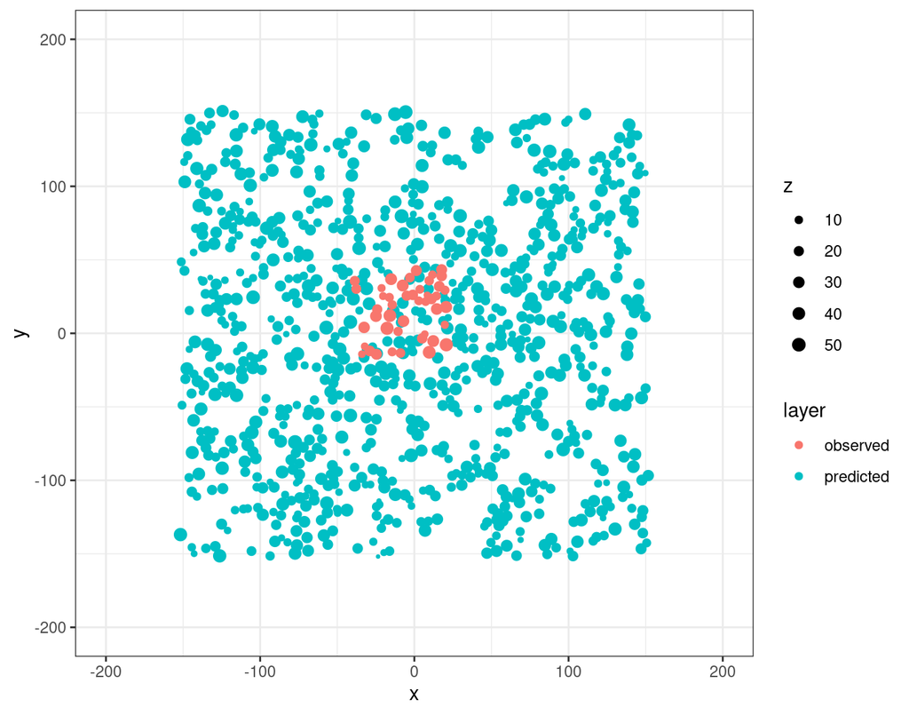

```r
vis2(sim$pred, sim$obs)
```

Based on the shift we specified to the simulator, the observed map needs to be shifted ~9 units east and ~15 units south to align with the predicted map. Visually, you will be unlikely to find a perfect match because of the detection noise (false positives and false negatives) and spatial noise.

## Defining the alignment algorithm

### Objective function

The alignment algorithm is a grid search that accepts any objective function that can be applied to two data frames with x, y, and z columns representing tree positions. The objective function I have been using so far simply returns the mean distance to the nearest predicted point from each observed point (in 3D space), across all observed points. Note that this assumes we have heights for the observed trees, which will not always be the case. Here’s the definition:

```r
obj_mean_dist_to_closest
```

```
function(pred, obs, ...) {

  # Crop the predicted points to the x-y extent of the observed points +- 25%, so we don't waste
  # time if the user provided a predicted tree map that is much larger than the observed tree map
  pred_crop = crop_pred_to_obs(pred, obs)

  ## For each predicted point, get the closest observed point in x, y, z space
  # For each observed point, get the distance to every predicted point
  # TODO: Is it OK that multiple observed points may be matched to the same predicted point? Maybe
  # keep it simple for the sake of speed, if it can recover the correct shift
  dists = sqrt(outer(obs$x, pred_crop$x, "-")^2 +
                 outer(obs$y, pred_crop$y, "-")^2 +
                 outer(obs$z, pred_crop$z, "-")^2)

  # For each observed point, get the distance to the nearest predicted point
  min_dists = apply(dists, 1, min)

  # Summarize the alignment as the mean distance to the nearest predicted point
  objective = mean(min_dists)

  return(objective)
}
<environment: namespace:ofo>
```

Here’s an example of applying the objective function to the simulated data, without any shifting.

```r
obj_mean_dist_to_closest(sim$pred, sim$obs)
```

```
[1] 10.38611
```

Now let’s shift the observed data by the known offset and see if the objective function improves.

```r
obs_unshifted = sim$obs |>
  dplyr::mutate(x = x + 9.25,
                y = y - 15.5)

obj_mean_dist_to_closest(sim$pred, obs_unshifted)
```

```
[1] 6.860669
```

It should be lower!

### Grid search

The grid search is defined by `find_best_shift_grid`. It uses a customizable search window and search increment. It is wrapped by the user-facing function `find_best_shift`, which allows the user to specify either a grid search or an optimizer. (I didn’t have any luck with optimizers due to the discontinuous nature of the objective function.) When `grid` is selected as the method for `find_best_shift`, a two-stage grid search is performed, where the first stage is a coarse search (search window of 50 m with an increment of 2 m), and the second stage is a fine search (search window of 3 m with an increment of 0.25 m, centered on the optimal shift identified by the coarse search).

First we demonstrate the underlying single-stage `find_best_shift_grid` function. It runs the computation of the objective function for each grid point, in parallel.

```r
shift = find_best_shift_grid(sim$pred, sim$obs,
                     objective_fn = obj_mean_dist_to_closest,
                     search_window = 50,
                     search_increment = 2)
shift
```

```
$best_shift
    shift_x shift_y objective
813      44     -20  6.750408
```

As a reminder, the true shift is 9.25, -15.5.

We could now run another single-stage grid search, but centered on this shift, with a smaller search window and increment.

```r
find_best_shift_grid(sim$pred, sim$obs,
                     objective_fn = obj_mean_dist_to_closest,
                     search_window = 3,
                     search_increment = 0.25,
                     base_shift_x = shift$best_shift$shift_x,
                     base_shift_y = shift$best_shift$shift_y)
```

```
$best_shift
    shift_x shift_y objective
235   43.25  -20.75  6.689624
```

Hopefully the result is closer to the true shift.

We can run the two-stage grid search all at once with `find_best_shift`.

```r
find_best_shift(sim$pred, sim$obs,
                objective_fn = obj_mean_dist_to_closest,
                method = "grid")
```

```
8.873 sec elapsed
```

```
  shift_x shift_y shift_obj median_obj n_tested_coarse n_trees_obs time_taken
1   43.25  -20.75  6.689624   8.841359            2601          45      8.873
```

## Quantifying the success rate

Each simulated tree map is a random draw, so we can’t read much into the alignment success (or failure) on a single simulated map to tell us whether our algorithm is good at recovering the shift. The function `calc_alignment_success_rate` runs the alignment algorithm on `n_tries` simulated maps and returns the proportion of times the true shift is recovered (within a 3 m tolerance). The argument has a `...` argument that takes all the arguments to be passed to `simulate_tree_maps`.

```r
set.seed(123)
result = calc_alignment_success_rate(n_tries = 4, # set to at least 100 except for testing
                                     parallel = TRUE,
                                     trees_per_ha = 300,
                                     trees_per_clust = 5,
                                     cluster_radius = 5,
                                     obs_extent = 60,
                                     horiz_jitter = 3,
                                     vert_jitter = 5, # max of 5
                                     height_bias = 0,
                                     false_pos = 0.25,
                                     false_neg = 0.25,
                                     drop_observed_understory = TRUE)
```

```
28.927 sec elapsed
29.398 sec elapsed
29.295 sec elapsed
29.031 sec elapsed
```

```r
result
```

```
  n_gridcells_per_trial mean_n_trees_obs mean_secs_per_trial recovery_rate
1                  2601             30.2               29.16          0.75
  n_trials
1        4
```

Ideally we’d want to run this with at least 100 tries to get a good estimate of the success rate. But it takes a long time due to how slow the grid search is. This function may serve as a basis for evaluating different objective functions or optimizers against each other to see which is best (and fastest) at recovering the shift.

## Other approaches

### ICP

I implemented PDAL’s ICP algorithm here. It is fast but does not work very well in this context. It requires PDAL to be installed and accessible via the command line, as this function makes a system call to PDAL.

```r
find_best_shift_icp(sim$pred, sim$obs)
```

[output not shown]

```
0.188 sec elapsed
```

```
   shift_x   shift_y n_trees_obs time_taken
1 1.390333 -4.170244          45      0.188
```

If we thought this algorithm had potential, we could add it as a option for the `method` argument of `find_best_shift` (which currently only accepts “grid” or “optim” (with any arbitrary function)).

### CPD (Coherent Point Drift) for point cloud matching.

I think the CPD algorithm has the greatest potential to work well in this context. I [could not get](https://github.com/PDAL/PDAL/issues/2100) the [PDAL implementation](https://pdal.io/en/2.6.0/stages/filters.cpd.html) to work due to the need to build PDAL with additional dependencies that appear to have their own dependency challenges. However, there is a [Python implemention of CPD](https://github.com/siavashk/pycpd) that I think we should test. If we want to integrate it with the `ofo` R package, we could either use `reticulate` to call Python from R, or we could write a command line binding for the CPD Python script and make a system call from R.

The biggest challenge I see with using a predefined poing cloud matching algorithm for this task is what we do with datasets where the observed trees do not have heights. When we are writing custom objective functions, we could optimize a parameter to estimate height from DBH (which should always be measured). But I’m not sure how we would do this with a predefined algorithm like CPD. The best solution I can think of is to use some “global average” height~DBH relationship to convert DBHs to heights before running the algorithm.

### MEE-based matching & F-score

As an alternative objective function, I also implemented the tree matching algorithm from the [MEE paper](https://besjournals.onlinelibrary.wiley.com/doi/10.1111/2041-210X.13860), which ultimately yields an F-score summarizing the recall and precision. However, it is (comparatively) very slow and impractical to use within the grid search approach. It is defined in the function `obj_mee_matching`.

## Next steps

- Implement CPD
- Implement an approach to align an oberved tree map that does not have heights, instead relying on DBH and somehow translating it into height, either as a component of the optimization or as a preprocessing step, assuming some global average height~DBH relationship.